# Study Questions: Introduction to Dynamic Longitudinal Modeling

Manuel Voelkle

2025-07-01

## 1. Terminology: Discrete vs. Continuous Time

**Question:**  
Match the following discrete-time parameters with their continuous-time counterparts based on the terminology table shown in the presentation. Then, briefly describe what each parameter represents in modeling dynamic systems.

| Discrete-Time Parameter | Continuous-Time Equivalent | Description |
| --- | --- | --- |
| $A^{*}$ (autoregression) |  |  |
| $Q^{*}$ (process error) |  |  |
| $b^{*}$ (intercepts) |  |  |

**Sample Solution**

| Discrete-Time Parameter | Continuous-Time Equivalent | Description |
| --- | --- | --- |
| $A^{*}$ (autoregression) | $A$ (Drift matrix) | Describes the rate of change between latent variables; models auto- and cross-effects. |
| $Q^{*}$ (process error) | $Q$ (Diffusion matrix) | Represents the variance/covariance of the system disturbances over time. |
| $b^{*}$ (intercepts) | $b$ | Intercepts governing the average level change in the latent process. |

These mappings are important because they clarify how discrete observations relate to the underlying continuous process, allowing for a more accurate and generalizable interpretation of system dynamics.

## 2. ctsem 1: ctsemOMX

**Question:**  
Familiarize yourself with ctsemOMX. Check out the help files of `?ctModel` and `?ctFit`.

**Sample Solution**

```r
library(ctsemOMX)
?ctModel
?ctFit
```

## 3. ctsem 2: Hands-on exercise using the `AnomAuth` dataset

**Question:**  
Examine the following code of a bivariate continuous time model using the `ctsemOMX` package and the provided `AnomAuth` dataset. Fit the model and examine the drift parameters. What do the results tell you about the relationship between Anomia and Authoritarianism?

```r
# Load required packages
if (!requireNamespace("ctsem", quietly = TRUE)) install.packages("ctsem")
if (!requireNamespace("ctsemOMX", quietly = TRUE)) install.packages("ctsemOMX")

library(ctsem)
library(ctsemOMX)
# Load example data
data(AnomAuth)

# Define the CT model
AnomAuthmodel <- ctModel(
  type = "omx",
  Tpoints = 5,
  n.latent = 2,
  n.manifest = 2,
  LAMBDA = matrix(c(1, 0, 0, 1), nrow = 2, ncol = 2),
  MANIFESTVAR = diag(0, 2),
  TRAITVAR = NULL,
  manifestNames = c("Y1", "Y2"),
  latentNames = c("Anomia", "Authorit")
)
```

```
Type "omx" is still supported but requires ctsemOMX package installation. "ct" or "dt" are recommended types.
```

```
CINT specified via single value -- filling 2 * 1 matrix:
```

```
     [,1]
[1,]  "0"
[2,]  "0"
```

```r
# Fit the model
AnomAuthfit <- ctFit(AnomAuth, AnomAuthmodel)
```

```
wide format data detected
```

```
Running ctsemCarefulFit with 14 parameters
```

```
Running ctsem with 14 parameters
```

```
Beginning initial fit attempt
```

```
Running ctsem with 14 parameters
```

```
 Lowest minimum so far:  23415.9290488423
```

```
Solution found
```

```
 Solution found!  Final fit=23415.929 (started at 85854.448)  (1 attempt(s): 1 valid, 0 errors)
```

```r
# Summarize the results
summary(AnomAuthfit)
```

```
$LAMBDA
   Anomia Authorit
Y1      1        0
Y2      0        1

$DRIFT
              Anomia   Authorit
Anomia   -0.44728197  0.2324980
Authorit  0.04329279 -0.1174662

$MANIFESTVAR
   Y1 Y2
Y1  0  0
Y2  0  0

$MANIFESTMEANS
         [,1]
[1,] 2.687441
[2,] 2.863378

$CINT
         [,1]
Anomia      0
Authorit    0

$DIFFUSION
               Anomia     Authorit
Anomia    0.473241907 -0.004610142
Authorit -0.004610142  0.154509557

$T0VAR
            Anomia  Authorit
Anomia   0.6328612 0.2447308
Authorit 0.2447308 0.4575771

$T0MEANS
                [,1]
Anomia   -0.18401201
Authorit -0.02065629

```

[output cut: 46 more lines]

```
$omxsummary$observedStatistics
[1] 13375

$omxsummary$<NA>
NULL

$omxsummary$degreesOfFreedom
[1] 13361

$omxsummary$Minus2LogLikelihood
[1] 23415.93


$message
[1] "For additional summary matrices and raw OpenMx parameter output, use argument verbose=TRUE"
```

**Sample Solution**

The drift matrix output reveals auto-effects and cross-effects between the two latent constructs. A negative value on the diagonal suggests stability or reversion to the mean. The off-diagonal values show directional effects: for instance, a larger value from Authoritarianism to Anomia indicates a stronger directional influence compared to the reverse. These results provide empirical insight into the theoretical claim that authoritarian attitudes might drive perceptions of social disorder (anomia).

## 4. ctsem 3: Hands-on exercise using the `ctExample1` dataset part 1

**Question:**  
Apply a bivariate continuous time model to the ctExample1 data provided with the package (without a TRAITVAR argument).

**Sample Solution**

```r
data(ctExample1)
ctExp1model <- ctModel(n.manifest=2, n.latent=2, Tpoints=6, LAMBDA=diag(2),
  manifestNames=c('LeisureTime', 'Happiness'),
  latentNames=c('LeisureTime', 'Happiness'))
```

```
Type "omx" is still supported but requires ctsemOMX package installation. "ct" or "dt" are recommended types.
```

```
CINT specified via single value -- filling 2 * 1 matrix:
```

```
     [,1]
[1,]  "0"
[2,]  "0"
```

```r
ctExp1modelfit <- ctFit(dat=ctExample1, ctmodelobj=ctExp1model)
```

```
wide format data detected
```

```
Running ctsemCarefulFit with 16 parameters
```

```
Running ctsem with 16 parameters
```

```
Beginning initial fit attempt
```

```
Running ctsem with 16 parameters
```

```
 Lowest minimum so far:  4345.86286368784
```

```
 OpenMx status code 6 not in list of acceptable status codes, (0,0)
```

[output not shown]

```
Beginning fit attempt 1 of at maximum 5 extra tries
```

```
Running ctsem with 16 parameters
```

```
 Lowest minimum so far:  4345.12378681939
```

```
 OpenMx status code 6 not in list of acceptable status codes, (0,0)
```

[output not shown]

```
Beginning fit attempt 2 of at maximum 5 extra tries
```

```
Running ctsem with 16 parameters
```

```
 Lowest minimum so far:  4345.12256326499
```

```
 OpenMx status code 6 not in list of acceptable status codes, (0,0)
```

[output not shown]

```
Beginning fit attempt 3 of at maximum 5 extra tries
```

```
Running ctsem with 16 parameters
```

```
 Lowest minimum so far:  4182.98695362433
```

```
 OpenMx status code 6 not in list of acceptable status codes, (0,0)
```

[output not shown]

```
Beginning fit attempt 4 of at maximum 5 extra tries
```

```
Running ctsem with 16 parameters
```

```
 Lowest minimum so far:  4182.8841788798
```

```
 OpenMx status code 6 not in list of acceptable status codes, (0,0)
```

[output not shown]

```
Beginning fit attempt 5 of at maximum 5 extra tries
```

```
Running ctsem with 16 parameters
```

```
 Fit attempt worse than current best:  4182.88626121157 vs 4182.8841788798
```

```
Retry limit reached
```

```
 Retry limit reached; Best fit=4182.8842 (started at 4727.4695)  (6 attempt(s): 6 valid, 0 errors)
```

```
 Uncertain solution found - consider parameter validity, try again, increase extraTries, change inits, change model, or check data!
```

```r
summary(ctExp1modelfit)
```

```
$LAMBDA
            LeisureTime Happiness
LeisureTime           1         0
Happiness             0         1

$DRIFT
            LeisureTime   Happiness
LeisureTime -0.02607706 -0.07310153
Happiness   -0.02341058 -0.06540411

$MANIFESTVAR
            LeisureTime Happiness
LeisureTime   0.7978798 0.0000000
Happiness     0.0000000 0.9916615

$MANIFESTMEANS
           [,1]
[1,] -121.18324
[2,]   56.70176

$CINT
            [,1]
LeisureTime    0
Happiness      0

$DIFFUSION
            LeisureTime Happiness
LeisureTime   0.2056858 0.1918137
Happiness     0.1918137 0.2724335

$T0VAR
            LeisureTime Happiness
LeisureTime   4.0405482 0.4220519
Happiness     0.4220519 1.1777920

$T0MEANS
                 [,1]
LeisureTime 126.58833
Happiness   -44.47411

```

[output cut: 48 more lines]

```
$omxsummary$observedStatistics
[1] 1200

$omxsummary$npsolMessage
[1] "The model does not satisfy the first-order optimality conditions to the required accuracy, and no improved point for the merit function could be found during the final linesearch (Mx status RED)"

$omxsummary$degreesOfFreedom
[1] 1184

$omxsummary$Minus2LogLikelihood
[1] 4182.884


$message
[1] "For additional summary matrices and raw OpenMx parameter output, use argument verbose=TRUE"
```

```
Plotting fit
```

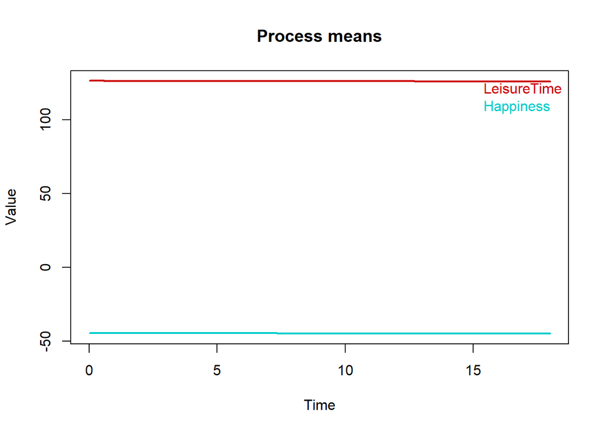

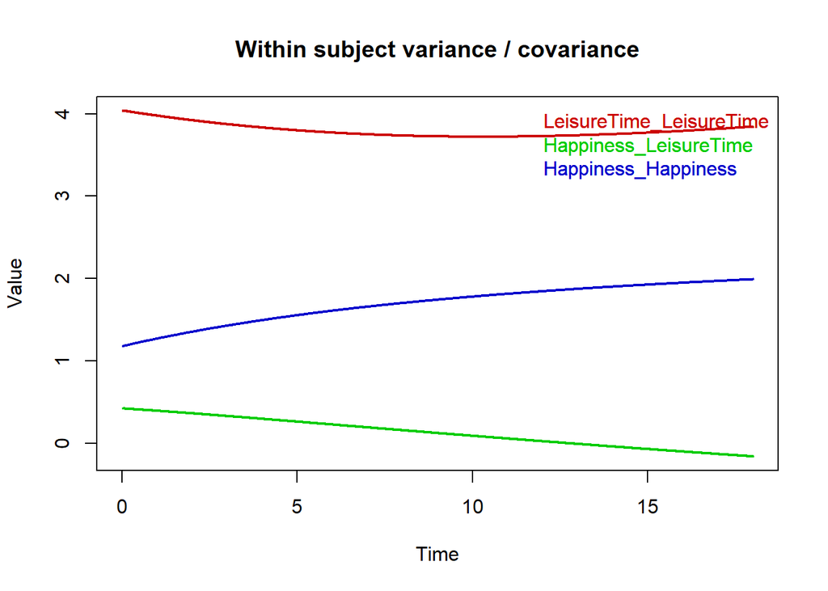

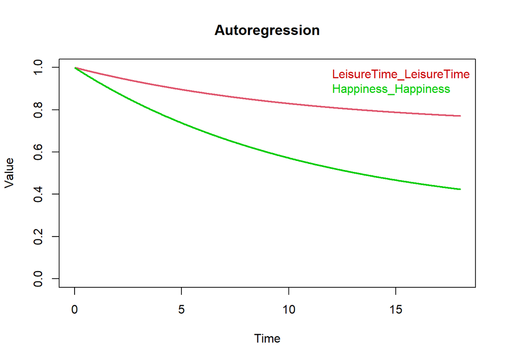

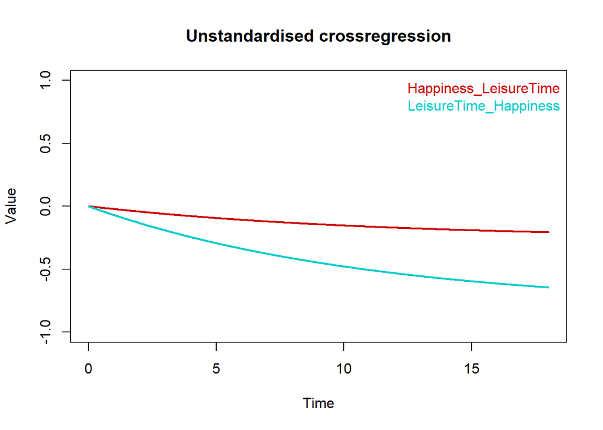

```r
plot(ctExp1modelfit, wait=FALSE)
```

## 5. ctsem 4: Redo the upper analysis with TRAITVAR=“auto”

**Question:**  
Apply a bivariate continuous time model to the ctExample1 data provided with the package. Include TRAITVAR=“auto”. Compare the results to the previous analysis. What happened? We did not discussed this in detail yet, but maybe you figure it out with the help of the helpfile/documentation.

**Sample Solution**

```r
data(ctExample1)
traitmodel <- ctModel(n.manifest=2, n.latent=2, Tpoints=6, LAMBDA=diag(2),
  manifestNames=c('LeisureTime', 'Happiness'),
  latentNames=c('LeisureTime', 'Happiness'), TRAITVAR="auto")
```

```
Type "omx" is still supported but requires ctsemOMX package installation. "ct" or "dt" are recommended types.
```

```
CINT specified via single value -- filling 2 * 1 matrix:
```

```
     [,1]
[1,]  "0"
[2,]  "0"
```

```r
traitfit <- ctFit(dat=ctExample1, ctmodelobj=traitmodel)
```

```
wide format data detected
```

```
Running ctsemCarefulFit with 19 parameters
```

```
Running ctsem with 19 parameters
```

```
Beginning initial fit attempt
```

```
Running ctsem with 19 parameters
```

```
 Lowest minimum so far:  4151.13132113275
```

```
Solution found
```

```
 Solution found!  Final fit=4151.1313 (started at 4301.6567)  (1 attempt(s): 1 valid, 0 errors)
```

```r
summary(traitfit)
```

```
$LAMBDA
            LeisureTime Happiness
LeisureTime           1         0
Happiness             0         1

$DRIFT
            LeisureTime  Happiness
LeisureTime  -0.1103333 -0.1340133
Happiness     0.3865287 -0.3439511

$MANIFESTVAR
            LeisureTime Happiness
LeisureTime   0.5668188 0.0000000
Happiness     0.0000000 0.8614892

$MANIFESTMEANS
          [,1]
[1,]  5.133643
[2,] 11.772996

$CINT
            [,1]
LeisureTime    0
Happiness      0

$DIFFUSION
            LeisureTime  Happiness
LeisureTime  0.39157688 0.02227203
Happiness    0.02227203 0.28770492

$T0VAR
            LeisureTime Happiness
LeisureTime   0.9615269 0.3435529
Happiness     0.3435529 0.8894892

$T0MEANS
                 [,1]
LeisureTime 0.2731795
Happiness   0.4746066

```

[output cut: 56 more lines]

```
$omxsummary$observedStatistics
[1] 1200

$omxsummary$<NA>
NULL

$omxsummary$degreesOfFreedom
[1] 1181

$omxsummary$Minus2LogLikelihood
[1] 4151.131


$message
[1] "For additional summary matrices and raw OpenMx parameter output, use argument verbose=TRUE"
```

```
Plotting fit
```

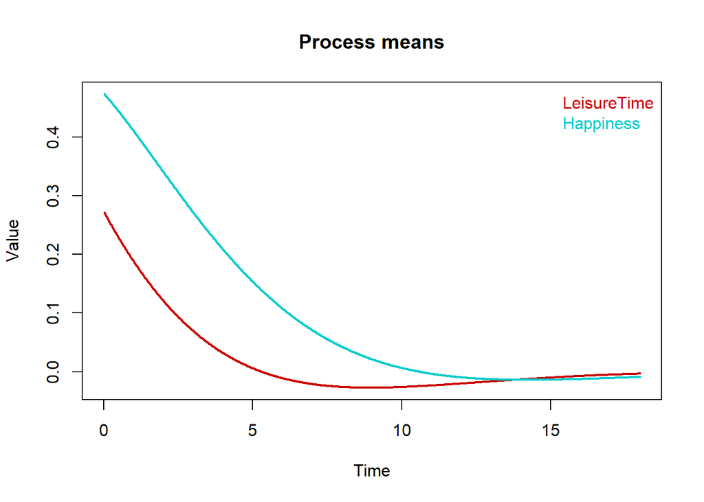

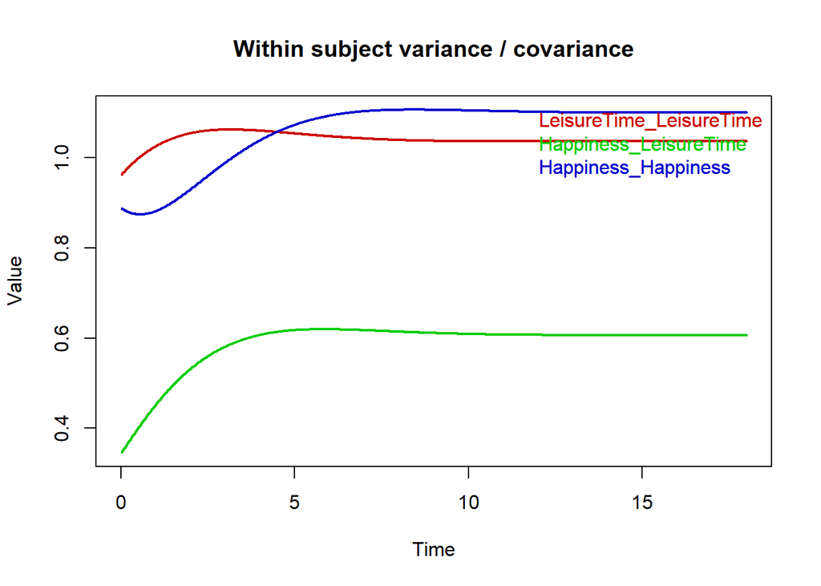

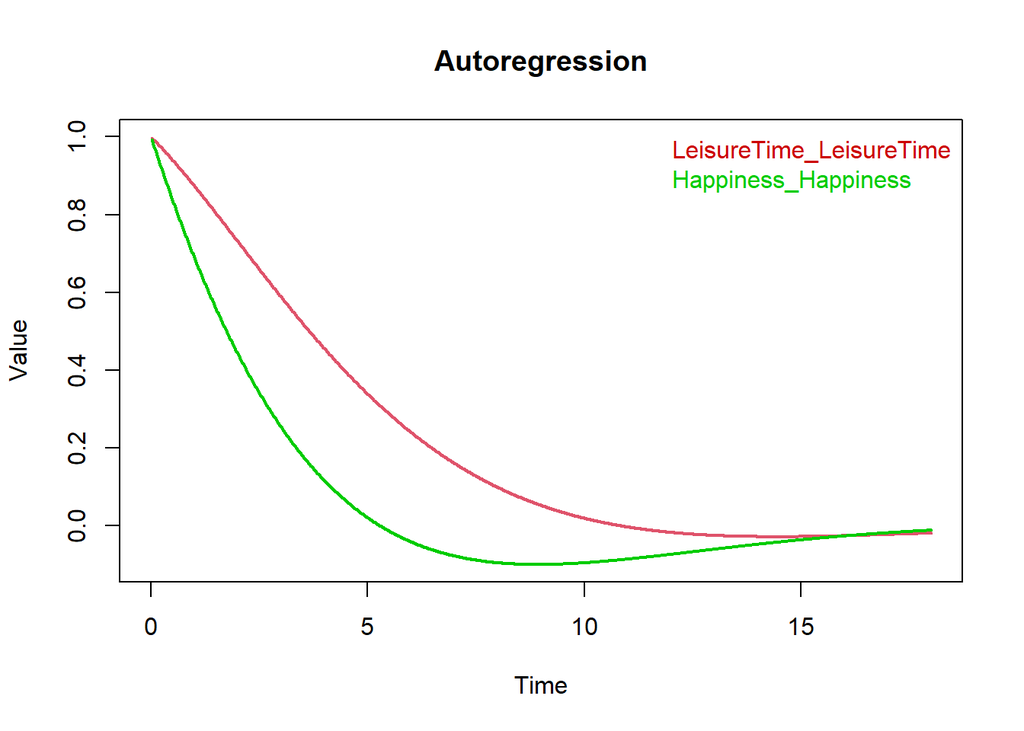

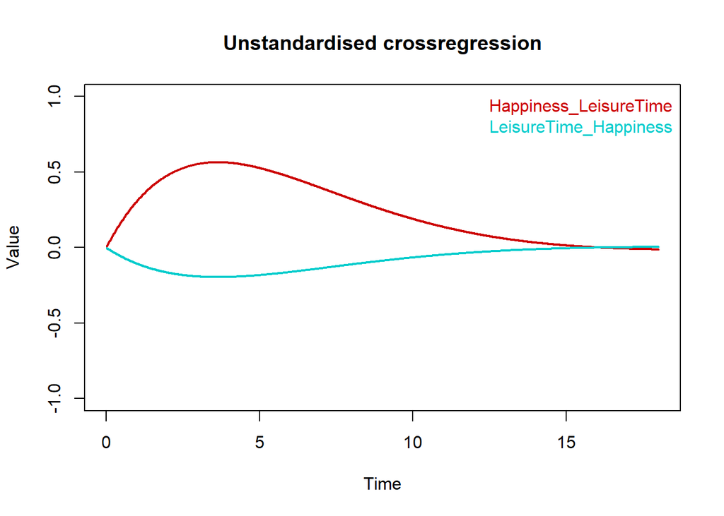

```r
plot(traitfit, wait=FALSE)
```

As compared to the previous example, there is now a positive effect of leisure time on happiness. The reason for these seemingly contradictory findings, is that we did not account for stable between person differences in the first analysis. This resulted in a conflation of between-person variance and within-person changes (cf. Simpsons paradox). In the second analysis, the `TRAITVAR="auto"` argument introduced a random intercept, which separates stable between person differences from within-person dynamics.

## 6. *Optional*: New ct analysis

**Question:**  
Choose a new longitudinal dataset (uni- or bivariate) and analyze the data using a basic dynamic ct model [for this task do not worry about preprocessing the data or whether the model is justified on theoretical grounds; it’s just about the method]. Share your approach/results with the group.